# Gender Pay Gap in the UK

Kostas Voulgaropoulos

August of 2021

# Intro

Much is told about **gender pay gap** and the **actions** needed (and taken) to overcome it.

But have we managed to defeat it? Are we paying women less than men? And if so, are we mitigating that inequality across time?

The **Gender Pay Gap Service** in the UK is concentrating relevant data since 2017, giving us the oppotrunity to seek answers to such questions.

The current report seeks to deploy them and provide insights.

## About the Dataset

Data is downloaded from the [Official Website of the **Gender Pay Gap Service**](https://gender-pay-gap.service.gov.uk/) and span across the period **2017 - 2021**.

After parsing all relevant CSVs, our dataframe more or less looks like:

```
## 'data.frame':    32759 obs. of  16 variables:
##  $ EmployerName           : chr  "\"Bryanston School\",Incorporated" "\"RED BAND\" CHEMICAL COMPANY, LIMITED" "118 LIMITED" "123 EMPLOYEES LTD" ...
##  $ PostCode               : chr  "DT11 0PX" "EH6 8NU" "CF24 2SA" "LS7 1AB" ...
##  $ Sic_Code               : int  85310 47730 61900 78300 93110 56210 93110 86900 56290 1470 ...
##  $ Description            : chr  "General secondary education" "Dispensing chemist in specialised stores" "Other telecommunications activities" "Human resources provision and management of human resources functions" ...
##  $ DiffMeanHourlyPercent  : num  18 2.3 1.7 41 -22 13.4 15.1 15 11.9 13.4 ...
##  $ DiffMedianHourlyPercent: num  28.2 -2.7 2.8 36 -34 8.1 2.8 0 0 8.5 ...
##  $ DiffMeanBonusPercent   : num  0 15 13.1 -69.8 -47 41.4 77.6 0 0 62.9 ...
##  $ DiffMedianBonusPercent : num  0 37.5 13.6 -157.2 -67 ...
##  $ MaleBonusPercent       : num  0 15.6 70 50 25 8.7 5.8 0 0 89.7 ...
##  $ FemaleBonusPercent     : num  0 66.7 57 73.5 75 3.2 4.2 0 0 73.3 ...
##  $ MaleLowerQuartile      : num  24.4 20.3 51 0 56 29.1 42.6 10 75.3 89.1 ...
##  $ FemaleLowerQuartile    : num  75.6 79.7 49 100 44 70.9 57.4 90 24.7 10.9 ...
##  $ MaleTopQuartile        : num  51.5 18.1 58 23 24 58.2 35.5 9 69.8 93.8 ...
##  $ FemaleTopQuartile      : num  48.5 81.9 42 77 76 41.8 64.5 91 30.2 6.2 ...
##  $ EmployerSize           : chr  "500 to 999" "250 to 499" "500 to 999" "250 to 499" ...
##  $ Year                   : int  2017 2017 2017 2017 2017 2017 2017 2017 2017 2017 ...
```

The rest of the Columns are self-explanatory.

[Here](https://gender-pay-gap.service.gov.uk/viewing/download) you can find the official descriptions published by the respective service.

Let’s start exploring our data.

# Overview

For starters, out of all companies, how many favor men and how many women?

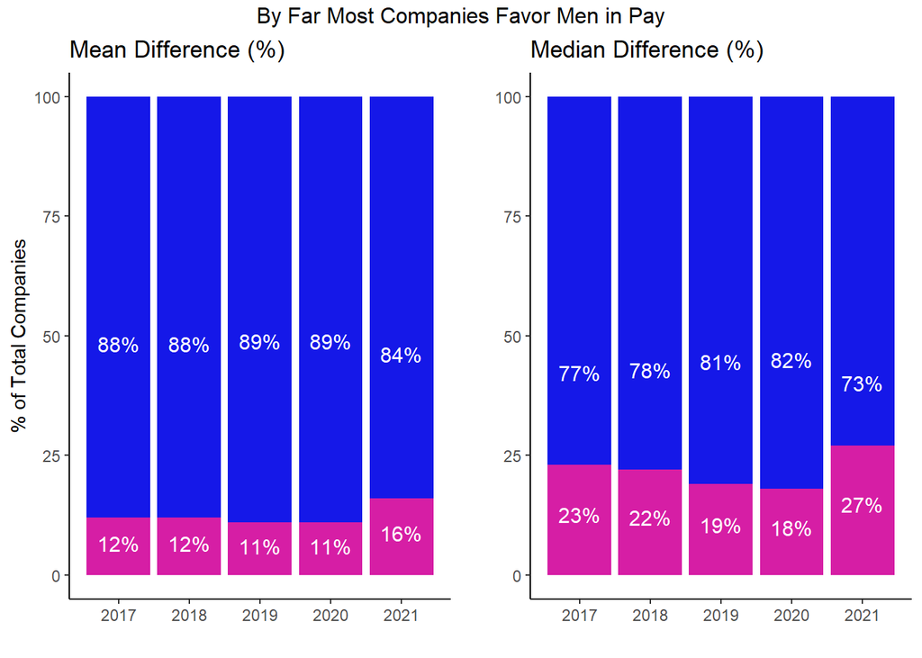

At first glance, the **vast majority of companies in the UK favor men over women in pay**.

When considering the **Median** Difference in pay, inequalities appear to smooth a bit. One possible explanation for that is that the highest paid employees are men. This fact forces the mean difference towards the men’s side.

But we will examine it further later in this report. For now, we will go on with the **Mean instead of the Median Difference** because **we want to take into account such inequalities derived from extremely high pays**.

Aside from that, a slight improvement seems to come into sight for 2021. But since this report is produced in mid-2021, **many companies haven’t reported data yet**.

A glance into the absolute numbers of companies favoring a gender might enlighten us:

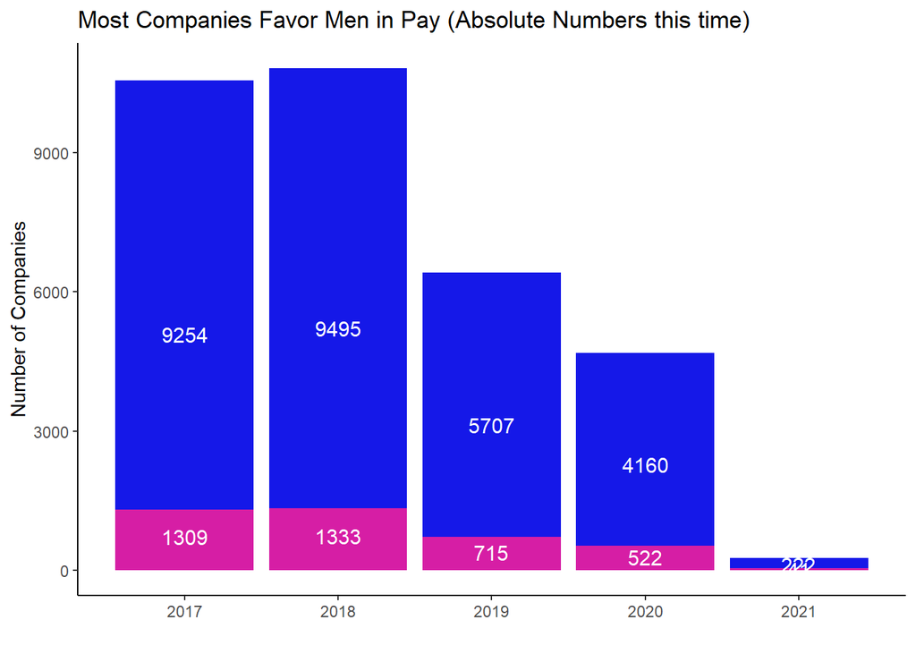

And indeed, data for 2021 is very scarce, just `263`.

That’s probably the reason why a positive change appeared in the earlier plot.

## Magnitude of Difference

So far, we just counted each difference no matter its magnitude. Even just a 0.01% difference is counted as favoring men (and a -0.01% for women respectively).

So, let’s take a look at the actual **numbers of differences** to enlighten their magnitude.

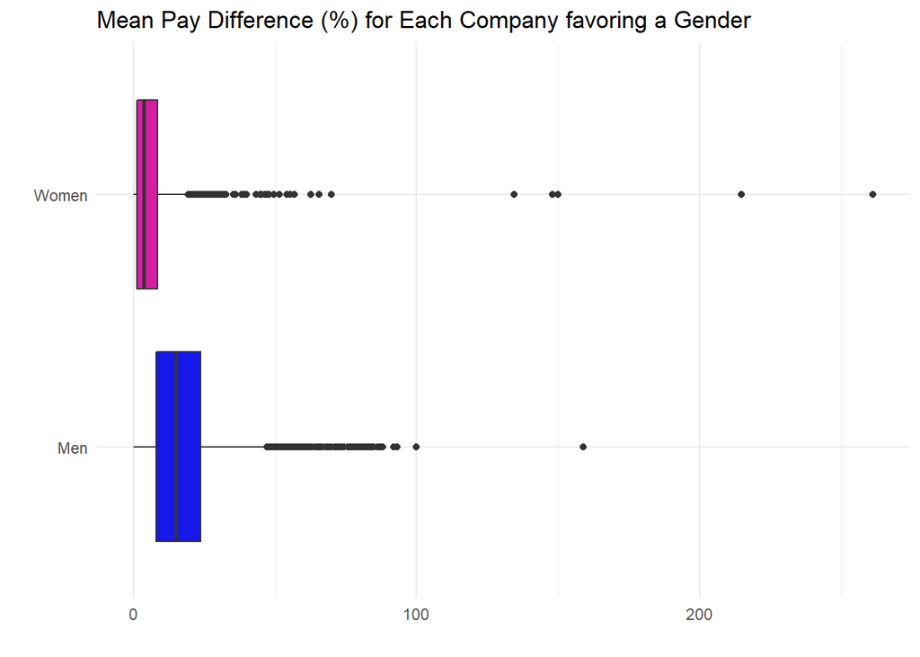

To interpret a Boxplot (like the preceding plot) it’s easier to consider an example of an 100 observations population.

In such an example:

- the **lower boundary** of each box represents the **25**th highest difference
- the **line** inside each box represents the **50**th highest difference
- the **upper boundary** of each box represents the **75**th highest difference
- **dots** represent **outliers**.

That being said, women’s distribution differences (i.e. all negative differences found in the dataset) is ridiculusly **closer to zero** than the respective men’s distribution of differences.

In addition, **men’s lower 25% starts where women’s 75% ends**, not to mention their **median difference** (`15.1333333`% for men against a mere `3.6666667`% for women).

Overall, it seems that **when a company favors women in pay, the difference is small and close to 0%**, while **when men are paid more, their difference from women is more significant**.

# Bonus

Apart from ordinary pay, many companies compensate their employees with bonuses.

## Percent of each Gender receiving a Bonus pay

As stated earlier, our dataset contains information about the percentage of the total (fe)male employees that received a bonus.

Let’s take a look at the **distribution of these percentages**:

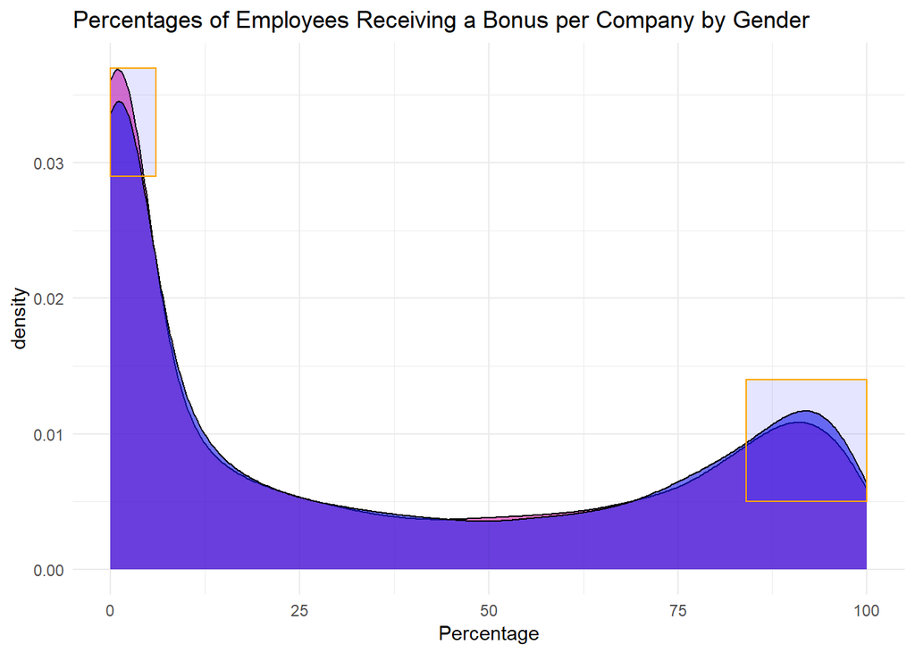

The two genders’ bonus percentages hopefully follow very similar distributions.

For the most part, the two distributions intersect.

The only parts where the differentiate are:

- at the very start (from 0% to 3%) where once again **women experience many more 0%s of bonus than men**
- at the very end, where men receive more 84%s to 95%s than do women.

## Differences in Bonus Pay

Apart from the percentage, what’s going on with the differences in bonus pay?

As with the ordinary pay section, we will explore:

- the percentage of total companies that favor one gender in bonus pay
- the magnitudes of those favors

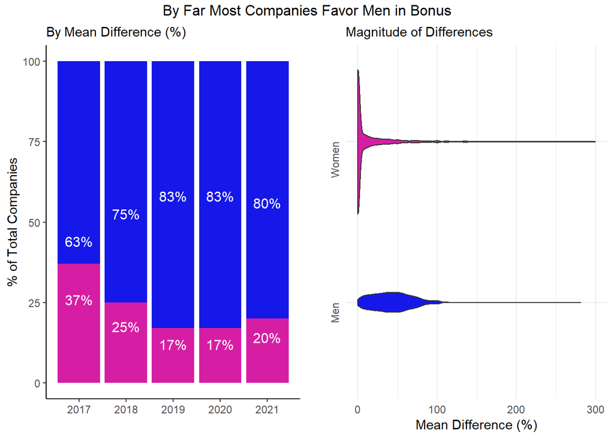

Very similarly with the ordinary pay,

- most companies pay greater bonuses to men than to women
- when women receive a greater bonnus, the difference with men’s bonus is **usually close to zero**, in contrast with men

# By Quartiles

Let’s now explore the rankings structure of the UK companies.

Our dataset contains information about the **composition** of their: * Lower * Lower Middle * Upper Middle and * Top level executives.

## Regardless of Year

Let’s first take a look at their composition regardless of the year:

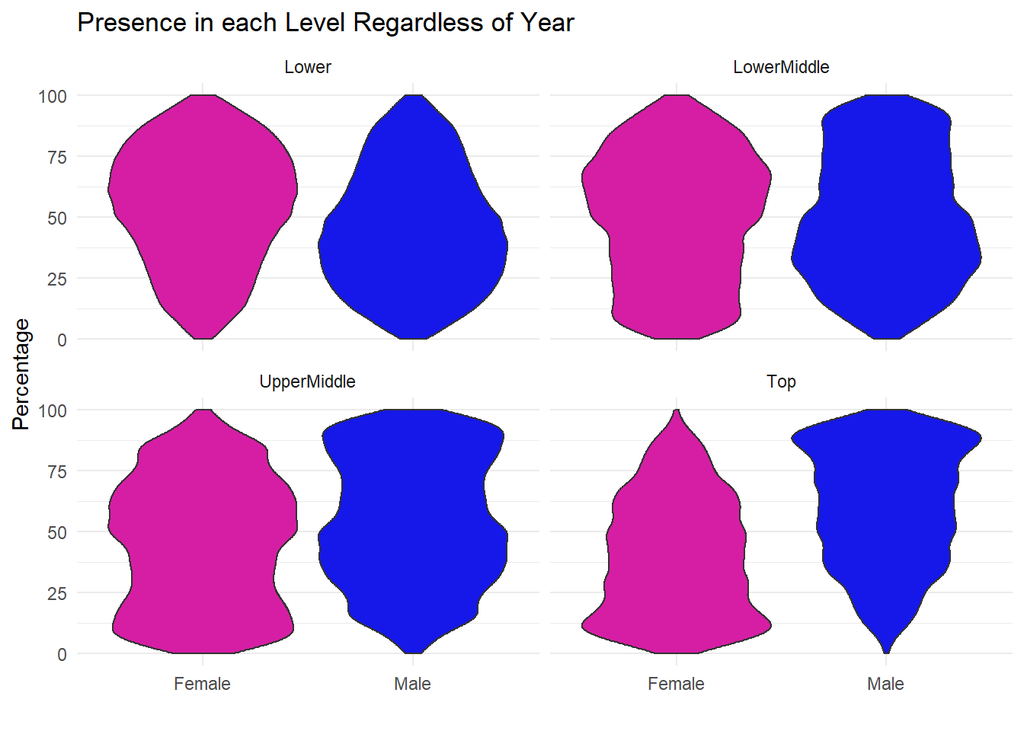

It seems that women **dominate lower and lower middle levels**, while **men prevail the top ones**.

In other words, most companies report 75%s of women (and 25%s for men respectively) in their lower quartile and vice versa for their top quartiles.

That also explains the discrepancy shown in the first plot between the mean and median pay. **Mean pay tends towards men** because they **hold the highest positions** (and thus the highest salaries) in most companies.

## By Quartiles and Year

Is this tendency weakened across time? Are things getting more diverse in the steps of the corporate ladder?

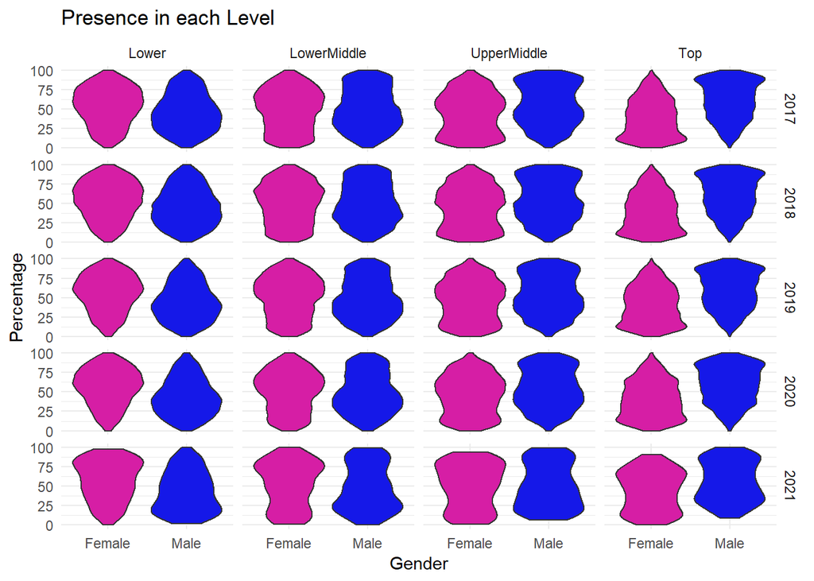

It appears that no.

The same pattern is observed every year. Men on top, women underneath them.

The only **exception** is year **2021**, which, as we saw earlier, contains way too **few observations** to present a clear picture.

# By Sector

Could some of the inequalities we observed so far be attributed to some sectors (such as Science, Technology, Engineering, Mathematics) that pay well and are dominated by a gender?

So first, which are the top 10 sectors that pay better each gender?

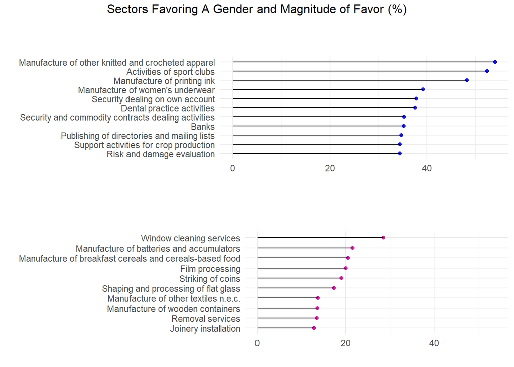

No pattern can be observed regarding the nature of those sectors.

But what can be observed is yet again the **magnitude of differences**.

The sector that pays women best, `Window cleaning services`, is paying women just `28.6` % more than is paying men.

On the other hand, the **10th** sector that pays men best, `Support activities for crop production`, is paying better even than women’s best, at `34.4`%.

Additionaly, out of all sectors, what percentage is paying men better than women?

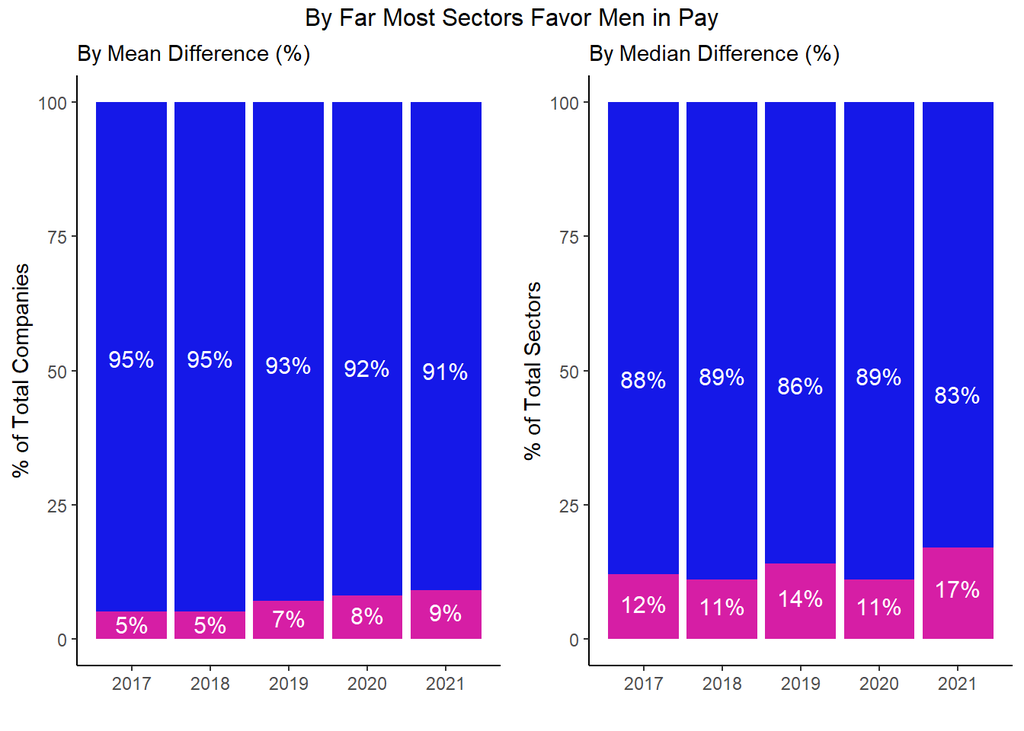

Yet again, most sectors pay men better than women.

# By Region

Apart from the sectors, could regions contribute to inequalities?

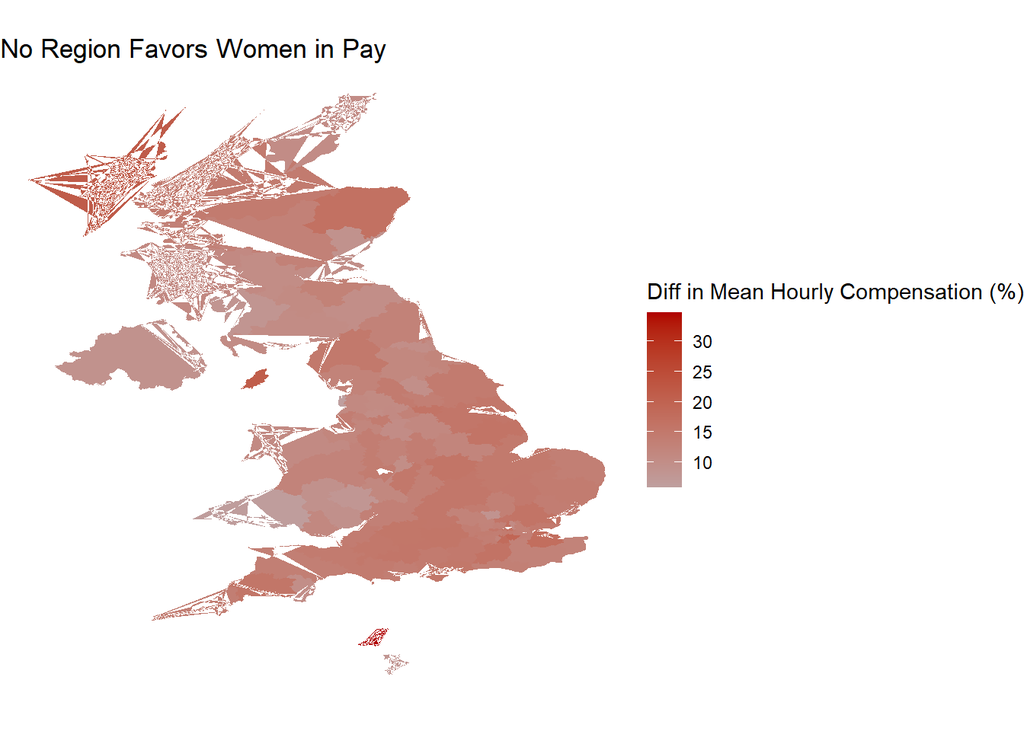

First of all, **in no region women are getting paid better than men**.

Apart from that, **no region seems to concentrate certain discrepancies** (either low or high), at least at first glance.

One could just say that the South has more sharpened inequalities in comparison to the British North, but still needs further examination.

# By Employer Size

Could employer Size be a factor that determines the gender pay gap?

Let’s take a look at each size’s average difference of pay by gender:

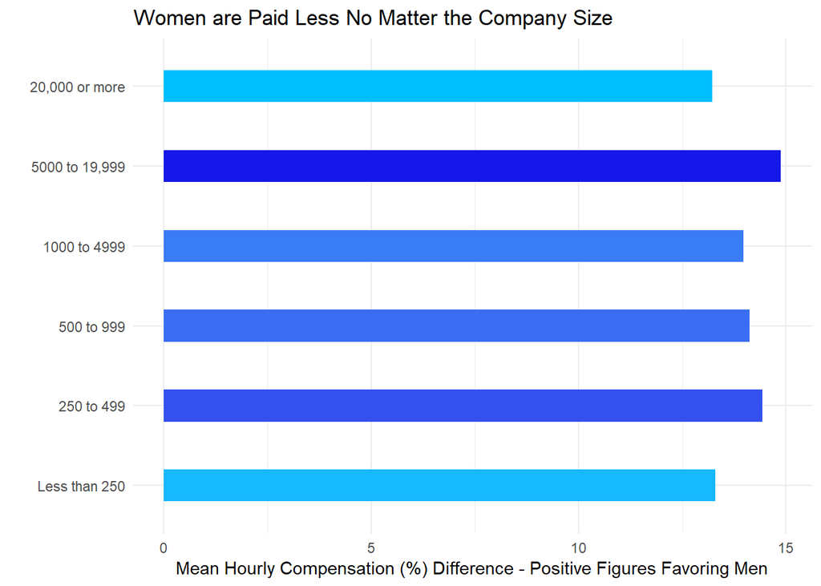

Pretty much **pay is biased towards men** no matter the size of company.

# Conclusion

- **Overall**, women are paid less than men, both in terms of **ordinary pay** and **bonus**.
- **Upper level** quartiles of the corporate ladder are dominated by **men**, while **lower** ones are dominated by **women**.
- In the majority of **sectors** women are on average paid less than men.
- In all **regions** and **company sizes**, women are on average paid less than men.